# Analysis of RNA-Seq data: gene-level exploratory analysis and differential expression

# Contents

This instructional material is a derivative of materials

http://www-huber.embl.de/users/klaus/Teaching/DESeq2Predoc2014.html#statistical-testing-of-differential-expression

designed by Bernd Klaus[2] and Wolfgang Huber [2], based on material by Michael Love [1] and Simon Anders [2],

[1] Department of Biostatistics, Dana-Farber Cancer Institute and Harvard School of Public Health, Boston, US;

[2] European Molecular Biology Laboratory (EMBL), Heidelberg, Germany.

# 1 Preparations

We first set global chunk options and load the neccessary packages.

```r
library(BiocStyle)
library(rmarkdown)
library(geneplotter)
library(ggplot2)
library(plyr)
library(LSD)
library(DESeq2)
library(gplots)
library(RColorBrewer)
library(stringr)
library(topGO)
library(genefilter)
library(biomaRt)
library(dplyr)
library(EDASeq)
library(fdrtool)
library(org.Mm.eg.db)

data.dir <- file.path("/g/huber/users/klaus/Data/NCBI")
```

In this document we introduce a workflow for a typical RNA–Seq data analysis. We start from a “count table”, which summarizes the number of sequence reads mapping to each of the genes and discuss quality control, differential expression and enrichment analysis of the data. Important aspects of the `R` language and [Bioconductor](http://bioconductor.org/) data structures for high–dimensional genomic data are discussed along the way.

We re—analyze RNA–Seq data obtained by comparing the expression profiles of WT mice to mice harboring a deletion that is associated with a MYC enhancer which is required for proper lip/palate formation. The data was published along with the following paper:

- [Uslu et. al. – Long–range enhancers regulating Myc expression are required for normal facial morphogenesis, 2014](http://dx.doi.org/10.1038/ng.2971)

Note that in the workflows below, we do not aim at giving a comprehensive treatment of of possible options, but rather try to introduce sensible default approaches for the necessary steps. It is based on a protocol published in Nature Methods, which contains more detailed information on various steps. Additionally, the “RNA–Seq workflow” is well worth reading and contains a lot of additional background information.

- [Anders et. al. – Count–based differential expression analysis of RNA sequencing data using R and Bioconductor, 2013](http://dx.doi.org/10.1038/nprot.2013.099)
- [Love et. al. – RNA–Seq workflow: gene–level exploratory analysis and differential expression](http://master.bioconductor.org/help/workflows/rnaseqGene/)

This lab will walk you through an end–to-end RNA–Seq differential expression workflow, using *DESeq2* along with other Bioconductor packages.

# 2 Preparing count matrices

As input, the *DESeq2* package expects count data as obtained, e.g., from RNA–Seq or another high–throughput sequencing experiment, in the form of a matrix of integer values. The value in the *i*–th row and the *j*–th column of the matrix tells how many reads have been mapped to gene *i* in sample *j*. Analogously, for other types of assays, the rows of the matrix might correspond e.g., to binding regions (with ChIP–Seq) or peptide sequences (with quantitative mass spectrometry).

The count values must be raw counts of sequencing reads. This is important for *DESeq2*’s statistical model to hold, as only the actual counts allow assessing the measurement precision correctly. Hence, please do not supply other quantities, such as (rounded) normalized counts, or counts of covered base pairs — this will only lead to nonsensical results.

# 3 Aligning reads to a reference and feature counting

The computational analysis of an RNA–Seq experiment begins earlier: what we get from the sequencing machine is a set of FASTQ files that contain the nucleotide sequence of each read and a quality score at each position. These reads must first be aligned to a reference genome or transcriptome. It is important to know if the sequencing experiment was single–end or paired–end, as the alignment software will require the user to specify both FASTQ files for a paired–end experiment. The output of this alignment step is commonly stored in a file format called [SAM/BAM](http://samtools.github.io/hts-specs).

A number of software programs exist to align reads to the reference genome, and the development is too rapid for this document to provide an up–to–date list. We recommend consulting benchmarking papers that discuss the advantages and disadvantages of each software, which include accuracy, ability to align reads over splice junctions, speed, memory footprint, and many other features.

The reads for this experiment were aligned to the Ensembl release 66 mouse reference genome using [TopHat](http://ccb.jhu.edu/software/tophat/index.shtml) obtained packaged with a GTF (gene annotation) file from the project. The Python library HTSeq was then used to count the aligned reads to features. All of these steps are treated in detail in the references given above.

For a full example of using the *HTSeq* Python package for read counting, please see the *pasilla* vignette. For an example of generating the *DESeqDataSet* from files produced by *htseq–count*, please see the *DESeq2* vignette.

We now obtain the count table of the experiment directly from a pre–saved file.

```r
load(url("http://www-huber.embl.de/users/klaus/geneCounts.RData"))
DESeq2Table
```

```
## class: DESeqDataSet
## dim: 37991 8
## metadata(1): version
## assays(1): counts
## rownames(37991): ENSMUSG00000000001 ENSMUSG00000000003 ... ENSMUSG00000093788
##   ENSMUSG00000093789
## rowData names(0):
## colnames(8): WT-SRR1042885 WT-SRR1042886 ... Del_8_17_homo-SRR1042891
##   Del_8_17_homo-SRR1042892
## colData names(3): condition sampleNO fastq
```

# 4 The *DESeqDataSet* class, column and row metadata

Bioconductor software packages often define and use a custom class for their data object, which makes sure that all the needed data slots are consistently provided and fulfill the requirements. In addition, Bioconductor has general data classes (such as the *SummarizedExperiment*) that can be used to move data between packages.

In *DESeq2*, the custom class is called *DESeqDataSet*. It is built on top of the *SummarizedExperiment* class (in technical term, it is a subclass), and it is easy to convert *SummarizedExperiment* instances into *DESeqDataSet* and vice versa.  
One of the main differences is that the `assay` slot is instead accessed using the *count* accessor, and the class enforces that the values in this matrix are non–negative integers.

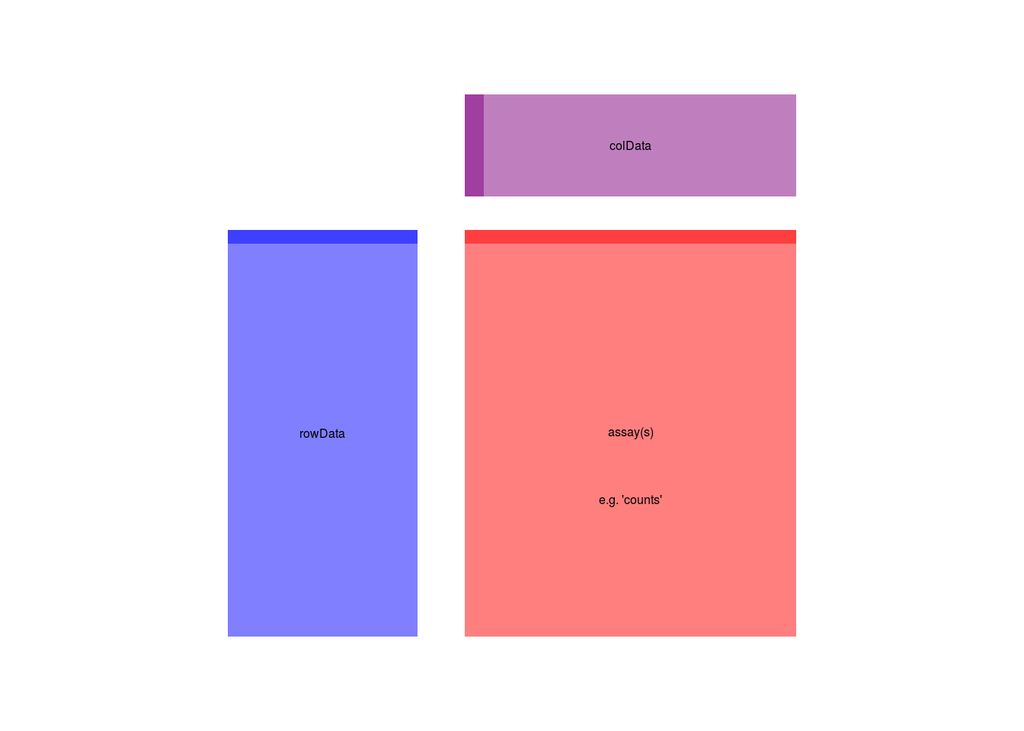

Here we show the component parts of a *SummarizedExperiment* object, and also its subclasses, such as the *DESeqDataSet* which we downloaded.

The `assay(s)` (red block) contains the matrix (or matrices) of summarized values, the `rowData` (blue block) contains information about the genomic ranges, and the `colData` (purple block) contains information about the samples or experiments. The highlighted line in each block represents the first row (note that the first row of `colData` lines up with the first column of the `assay`.

We can investigate the content of the downloaded *DESeqDataSet* by looking at the counts in the `assay` slot, the phenotypic data about the samples in `colData` (sample information), and the data about the genes in the `rowData` (information on genomic features) slot.

```r
DESeq2Table
```

```r
head(assay(DESeq2Table))
```

[output not shown]

```r
colSums(assay(DESeq2Table))
```

[output not shown]

```r
colData(DESeq2Table)
```

[output not shown]

```r
rowData(DESeq2Table)
```

[output not shown]

```r
mcols(rowData(DESeq2Table))
```

[output not shown]

The `colData` slot contains all the sample metadata.

```r
colData(DESeq2Table)
```

[output not shown]

At this point, we have counted the reads which overlap the genes in the gene model we specified. Note that the class `DataFrame` is a [Bioconductor](http://bioconductor.org/) variant of the standard `data.frame` class in `R`. which has among other things a more sensible print funtion, only showing the head and the tail of the table.

**Before we proceed, now correct an annotation error: the samples SRR1042891 and SRR1042886 have the opposite genotype**

```r
con <- as.character(colData(DESeq2Table)$condition)
con[2] <- "Del_8_17_homo"
con[7] <- "WT"
colData(DESeq2Table)$condition <- factor(con)
```

We can now move on to the actual differential expression analysis steps after specifying an appropriate *design*.

# 5 Experimental design and the design formula

The *DESeqDataSet* has an associated *design formula*. The design is specified at the beginning of the analysis, as it will inform many of the *DESeq2* functions how to treat the samples in the analysis (one exception is the size factor estimation, i.e., the adjustment for differing library sizes, which does not depend on the design formula). The design formula tells which variables in the column metadata table (`colData`) specify the experimental design and how these factors should be used in the analysis.

The simplest design formula for differential expression would be `~ condition`, where `condition` is a column in `colData(DESeq2Table)` which specifies which of two (or more groups) the samples belong to. This is also what we will be using for the data at hand.

You can use `R`’s formula notation to express any experimental design that can be described within an ANOVA–like framework. Note that *DESeq2* uses the same formula notation as, for instance, the *lm* function of base `R`. If the question of interest is whether a fold change due to treatment is different across groups, interaction terms can be included using models such as `~ group + treatment + group:treatment`. More complex designs such as these are covered in the *DESeq2* vignette.

# 6 Quality control and Normalization of the count data

Having created a count table and fed it into a DESeq2 object, the next step in the workflow is the quality control of the data. Let’s check how many genes we capture by counting the number of genes that have non–zero counts in all samples.

```r
GeneCounts <- counts(DESeq2Table)
idx.nz <- apply(GeneCounts, 1, function(x) { all(x > 0)})
sum(idx.nz)
```

```
## [1] 16149
```

```r
### random sample from the count matrix
nz.counts <- subset(GeneCounts, idx.nz)
sam <- sample(dim(nz.counts)[1], 5)
nz.counts[sam, ]
```

```
##                    WT-SRR1042885 WT-SRR1042886 WT-SRR1042887 WT-SRR1042888 Del_8_17_homo-SRR1042889
## ENSMUSG00000037363            38            15            58            52                       47
## ENSMUSG00000029060           333           255           498           554                      381
## ENSMUSG00000078247            58            57            71            96                       73
## ENSMUSG00000045095           644           531          1105          1117                      800
## ENSMUSG00000071506             2             9            11            12                       11
##                    Del_8_17_homo-SRR1042890 Del_8_17_homo-SRR1042891 Del_8_17_homo-SRR1042892
## ENSMUSG00000037363                       23                       36                      100
## ENSMUSG00000029060                      175                      326                      951
## ENSMUSG00000078247                       37                       57                      190
## ENSMUSG00000045095                      336                      682                     2124
## ENSMUSG00000071506                        4                        8                       19
```

In a typical RNA-Seq experiment, there will be at least several thousand genes that are expressed in all samples. If the number of non–zero genes is very low, there is usually something wrong with at least some of the samples (e.g. the sample preparation was not done properly, or there was some problem with the sequencing).

# 7 Normalization

As different libraries will be sequenced to different depths, offsets are built in the statistical model of *DESeq2* to ensure that parameters are comparable.

The term normalization is often used for that, but it should be noted that the raw read counts are not actually altered. *DESeq2* defines a virtual reference sample by taking the median of each gene’s values across samples and then computes size factors as the median of ratios of each sample to the reference sample.

Generally, the ratios of the size factors should roughly match the ratios of the library sizes. Dividing each column of the count table by the corresponding size factor yields normalized count values, which can be scaled to give a counts per million interpretation.

Thus, if all size factors are roughly equal to one, the libraries have been sequenced equally deeply.

Count data sets typically show a (left–facing) trombone shape in average vs mean–difference plots (MA–plots), reflecting the higher variability of log ratios at lower counts. In addition, points will typically be centered around a log ratio of 0 if the normalization factors are calculated appropriately, although this is just a general guide.

In the code below we produce density estimates of the sample counts and pairwise mean–difference plots after the computation of the size factors. The MA–plots are saved to a file in order to avoid cluttering the document.

We first relevel the condition factor to make sure that we have the wild type samples as a base level. This will allow us to obtain the fold changes always as WT–deletion. We also rename the deletion level to “Del”.

```r
colData(DESeq2Table)$condition <- factor(colData(DESeq2Table)$condition, levels = c("WT", "Del"))
colData(DESeq2Table)$condition <- factor(ifelse(is.na(colData(DESeq2Table)$condition),  "Del", "WT"), levels = c("WT", "Del"))
```

We now estimate estimate the size factors an print them

```r
DESeq2Table <- estimateSizeFactors(DESeq2Table)
sizeFactors(DESeq2Table)
```

```
##            WT-SRR1042885            WT-SRR1042886            WT-SRR1042887            WT-SRR1042888
##                   0.8362                   0.6322                   1.3975                   1.3709
## Del_8_17_homo-SRR1042889 Del_8_17_homo-SRR1042890 Del_8_17_homo-SRR1042891 Del_8_17_homo-SRR1042892
##                   1.0086                   0.4473                   0.8602                   2.6086
```

```r
multidensity( counts(DESeq2Table, normalized = T)[idx.nz ,],
    xlab="mean counts", xlim=c(0, 1000))
```

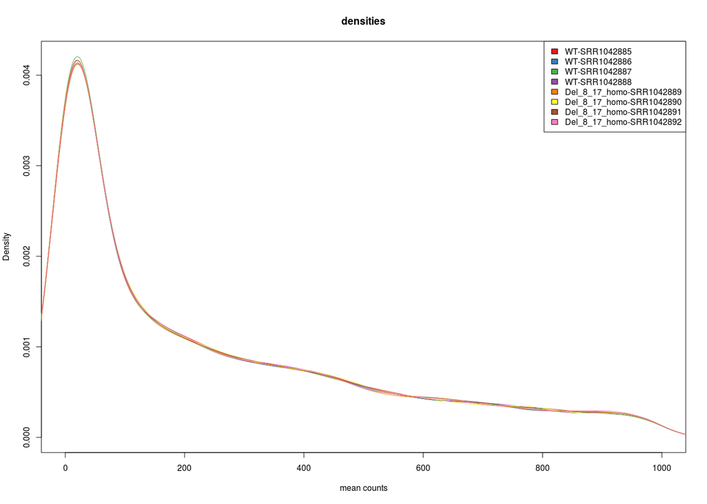

This is indeed the case here. The same holds true for the empircal cummulative distribution functions (ECDFs) which can be thought of as integrals of the densities and give the probability of observing a certain number of counts equal to $x$ or less given the data.

In an ECDF plot, the estimated probility is plotted on the y–axis and the count values on the x–axis. I.e. you can read of the median and other quantiles from this plot.

As already mentioned, if the normalization has worked, the ECDFs of the different samples should be overlapping.

```r
 multiecdf( counts(DESeq2Table, normalized = T)[idx.nz ,],
    xlab="mean counts", xlim=c(0, 1000))
```

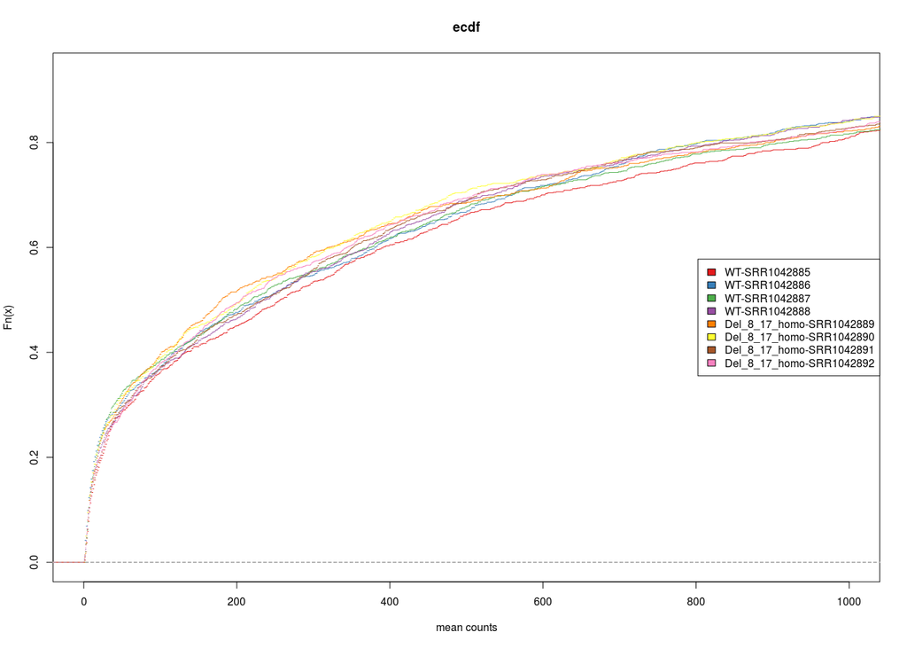

To further assess systematic differences between the samples, we can also plot pairwise mean–average plots: We plot the average of the log–transformed counts vs the fold change per gene for each of the sample pairs.

The function `combn` helps us to automatically generate all sample pairs and the function `MDPlot` from the *EDASeq* package then generates the the pairwise MA plots.

```r
pdf("pairwiseMAs.pdf")
  MA.idx = t(combn(1:8, 2))
  for( i in  seq_along( MA.idx[,1])){
   MDPlot(counts(DESeq2Table, normalized = T)[idx.nz ,],
        c(MA.idx[i,1],MA.idx[i,2]),
    main = paste( colnames(DESeq2Table)[MA.idx[i,1]], " vs ",
     colnames(DESeq2Table)[MA.idx[i,2]] ), ylim = c(-3,3))
    }
dev.off()
```

The plots look good, if there is no systematic shift between the samples, the log–fold–change should scatter around zero, which is the case here.

# 8 PCA and sample heatmaps

A useful first step in an RNA–Seq analysis is often to assess overall similarity between samples: Which samples are similar to each other, which are different? Does this fit to the expectation from the experiment’s design? We use the function to calculate the Euclidean distance between samples. To avoid that the distance measure is dominated by a few highly variable genes, and have a roughly equal contribution from all genes, we use it on the regularized log–transformed data.

The aim of the regularized log–transform is to stabilize the variance of the data and to make its distribution roughly symmetric since many common statistical methods for exploratory analysis of multidimensional data, especially methods for clustering and ordination (e.g., principal–component analysis and the like), work best for (at least approximately) homoskedastic data; this means that the variance of an observable quantity (i.e., here, the expression strength of a gene) does not depend on the mean.

In RNA–Seq data, however, variance grows with the mean. For example, if one performs PCA directly on a matrix of normalized read counts, the result typically depends only on the few most strongly expressed genes because they show the largest absolute differences between samples.

A simple and often used strategy to avoid this is to take the logarithm of the normalized count values plus a small pseudocount; however, now the genes with low counts tend to dominate the results because, due to the strong Poisson noise inherent to small count values, they show the strongest relative differences between samples. Note that this effect can be diminished by adding a relatively high number of pseudocounts, e.g. 32, since this will also substantially reduce the variance of the fold changes.

As a solution, *DESeq2* offers the regularized–logarithm transformation, or rlog for short. For genes with high counts, the rlog transformation differs not much from an ordinary log2 transformation.

For genes with lower counts, however, the values are shrunken towards the genes’ averages across all samples. Using an empirical Bayesian prior in the form of a ridge penalty, this is done such that the rlog–transformed data are approximately homoskedastic. Note that the rlog transformation is provided for applications other than differential testing. For differential testing it is always recommended to apply the DESeq function to raw counts.

Note that we have changed the row names of the distance matrix to contain the genotype and the column to contain the sample ID, so that we have all this information in view when looking at the heatmap.

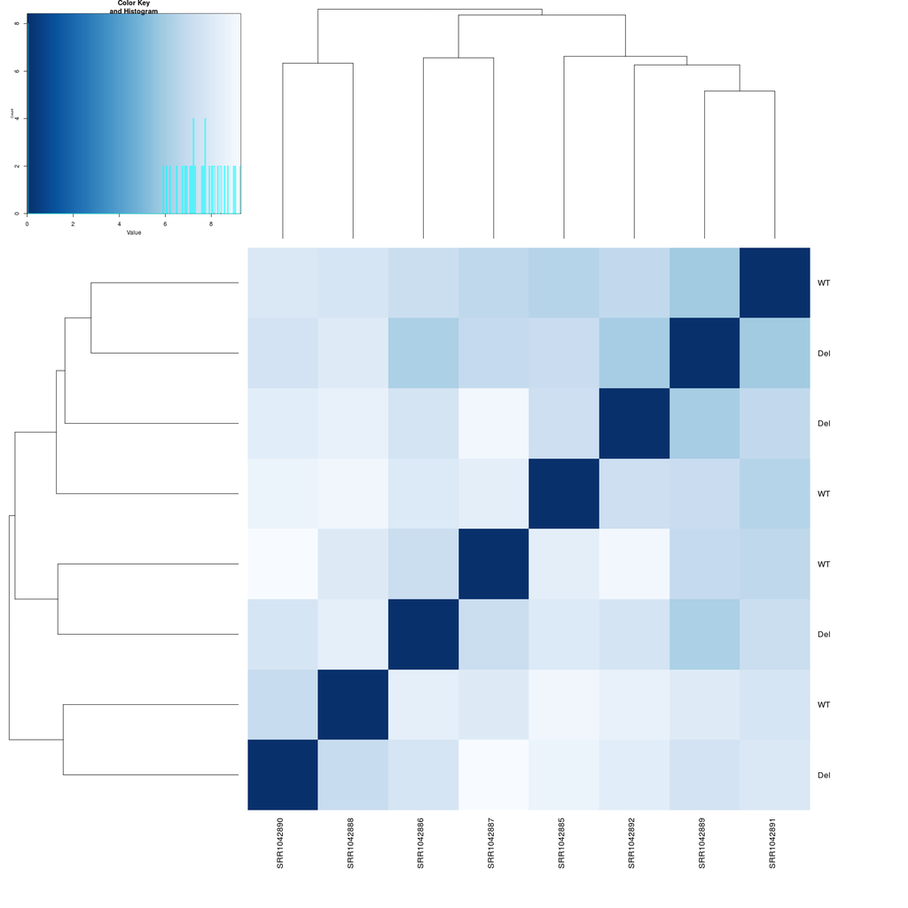

```r
rld <- rlogTransformation(DESeq2Table, blind=TRUE)


distsRL <- dist(t(assay(rld)))
mat <- as.matrix(distsRL)
rownames(mat) <-  colData(rld)$condition
colnames(mat) <-  colData(rld)$sampleNO

hmcol <- colorRampPalette(brewer.pal(9, "Blues"))(255)
heatmap.2(mat, trace="none", col = rev(hmcol), margin=c(13, 13))
```

Another way to visualize sample–to–sample distances is a principal–components analysis (PCA). In this ordination method, the data points (i.e., here, the samples) are projected onto the 2D plane such that they spread out optimally.

```r
ntop = 500

Pvars <- rowVars(assay(rld))
select <- order(Pvars, decreasing = TRUE)[seq_len(min(ntop,
        length(Pvars)))]

PCA <- prcomp(t(assay(rld)[select, ]), scale = F)
percentVar <- round(100*PCA$sdev^2/sum(PCA$sdev^2),1)
```

Since PCA can be slightly problematic with high dimensional data, we first use select only the 500 genes showing the highest variance.

We then use the function `prcomp` to compute the principal components. The resulting principal component scores, i.e. the coordinates of the samples in the space of the principal components can then be plotted.

For this we use the function `qplot` from *[ggplot2](http://cran.fhcrc.org/web/packages/ggplot2/index.html)*. *[ggplot2](http://cran.fhcrc.org/web/packages/ggplot2/index.html)* is a comprehensive plotting package for R, a very good tutorial is [here](http://jofrhwld.github.io/avml2012/). The function `qplot` is supposed to mimic the standard plotting function `plot` as closely as possible, but additional changes can be made, e.g. lattice–type graphics (splitting the plot by a factor of interest) can easily be generated.

Addition elements are changed by using `+` and the corresponding commands. In our PCA plot, we change the plotting colors used and the axis labels.

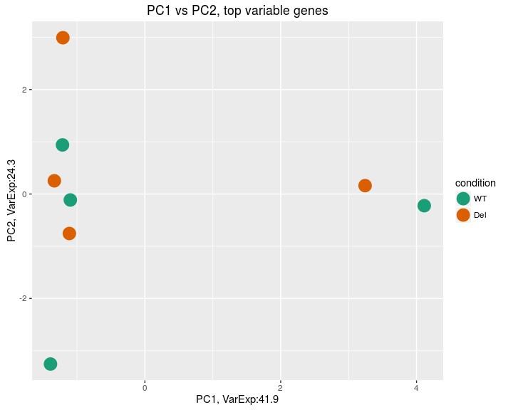

```r
dataGG = data.frame(PC1 = PCA$x[,1], PC2 = PCA$x[,2],
                    PC3 = PCA$x[,3], PC4 = PCA$x[,4],
                    sampleNO = colData(rld)$sampleNO,
                    condition = colData(rld)$condition)

(qplot(PC1, PC2, data = dataGG, color =  condition,
       main = "PC1 vs PC2, top variable genes", size = I(6))
 + labs(x = paste0("PC1, VarExp:", round(percentVar[1],4)),
        y = paste0("PC2, VarExp:", round(percentVar[2],4)))
 + scale_colour_brewer(type="qual", palette=2)
 )
```

We can clearly identify to outliers in the PCA plot, one in each experimental groups. These two outliers basically provide the separation according to the first principal component. Thus, they outliers will most likely increase the overall variability and thus diminish statistical power later when testing for differential expression. Therefore we remove them. We can get them by selecting only those samples that have a value greater than zero for the first principal component score. This can conveniently be done using the function `subset` and specifying the logical vector `dataGG$PC1 > 0` . `subset` will then return the sample names a positions where `dataGG$PC1 > 0` evaluates to `TRUE`.

```r
outliers <- as.character(subset(colnames(DESeq2Table), dataGG$PC1 > 0))
outliers
```

```
## [1] "WT-SRR1042888"            "Del_8_17_homo-SRR1042890"
```

```r
DESeq2Table <- DESeq2Table[, !(colnames(DESeq2Table) %in% outliers)]
```

We now produce the cluster heatmap and the PCA plot without the outliers.

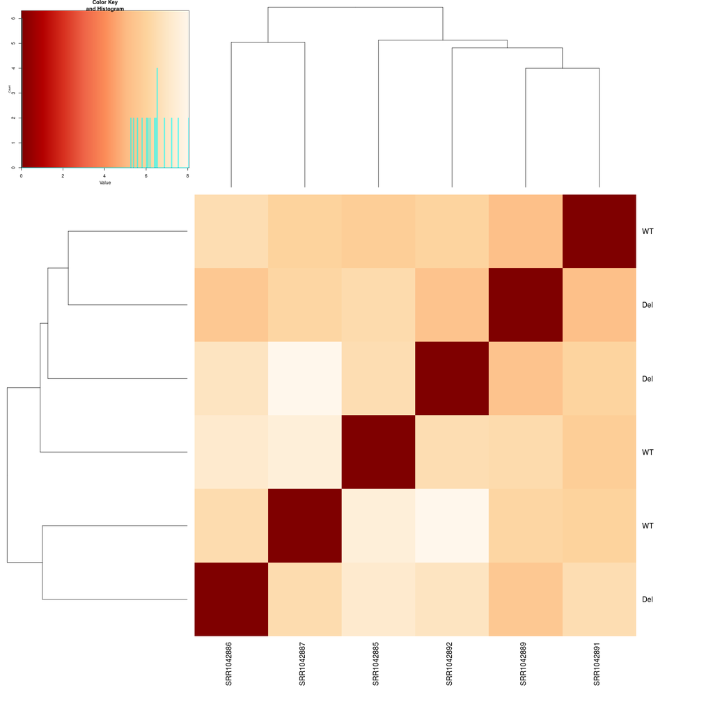

```r
rld <- rlogTransformation(DESeq2Table, blind=TRUE)

distsRL <- dist(t(assay(rld)))
mat <- as.matrix(distsRL)

rownames(mat) <-  colData(rld)$condition
colnames(mat) <-  colData(rld)$sampleNO

hmcol <- colorRampPalette(brewer.pal(9, "OrRd"))(255)
heatmap.2(mat, trace="none", col = rev(hmcol), margin=c(13, 13))
```

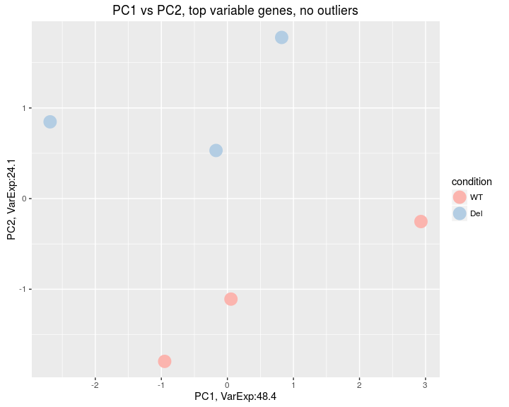

```r
Pvars <- rowVars(assay(rld))
select <- order(Pvars, decreasing = TRUE)[seq_len(min(ntop,
        length(Pvars)))]

PCA <- prcomp(t(assay(rld)[select, ]), scale = F)
percentVar <- round(100*PCA$sdev^2/sum(PCA$sdev^2),1)

dataGG = data.frame(PC1 = PCA$x[,1], PC2 = PCA$x[,2],
                    PC3 = PCA$x[,3], PC4 = PCA$x[,4],
                    sampleNO = colData(rld)$sampleNO,
                    condition = colData(rld)$condition)

(qplot(PC1, PC2, data = dataGG, color =  condition,
       main = "PC1 vs PC2, top variable genes, no outliers", size = I(6))
 + labs(x = paste0("PC1, VarExp:", round(percentVar[1],4)),
        y = paste0("PC2, VarExp:", round(percentVar[2],4)))
 + scale_colour_brewer(type="qual", palette=4)
 )
```

The separation between the two groups is not extremely clear, they do not cluster together in the heatmap and they also are only separated by the second principal component.

This will most likely result in only a modest number of differentially expressed genes and is in line with the small number of differentially expressed genes (~ 100) the authors report in the original publication.

# 9 Differential expression analysis

It is known that a standard Poisson model can only account for the technical noise in RNA–Seq data. In the Poisson model the variance is equal to the mean, while in real RNA–Seq data the variance is greater than the mean, a phenomenon often encountered in count data in general and referred to as “overdispersion”.

A popular way to model this is to use a Negative–Binomial-distribution (NB), which includes an additional parameter dispersion parameter $\alpha$ such that $E(NB) = \mu$ and

$$\text{Var[NB($\mu$, $\alpha$)]} = \mu + \alpha \cdot \mu^2$$

Hence, the variance is greater than the mean. *DESeq2* also uses the NB model. Hence, the first step in the analysis of differential expression, is to obtain an estimate of the dispersion parameter for each gene. The typical shape of the dispersion fit is an exponentially decaying curve. The asymptotic dispersion for highly expressed genes can be seen as a measurement of biological variability in the sense of a squared coefficient of variation: a dispersion value of 0.01 means that the gene’s expression tends to differ by typically $\sqrt{0.01}$ = 10% between samples of the same treatment group.

For weak genes, the Poisson noise is an additional source of noise, which is added to the dispersion. The function visualizes *DESeq2*’s dispersion estimates:

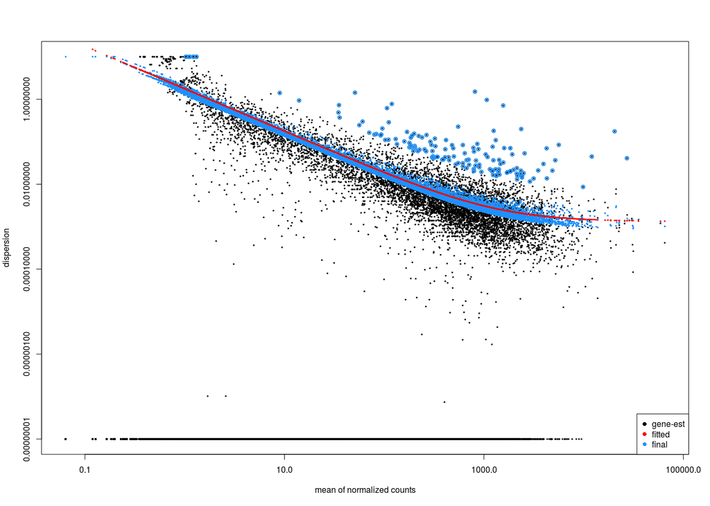

```r
DESeq2Table <- estimateDispersions(DESeq2Table)
plotDispEsts(DESeq2Table)
```

The black points are the dispersion estimates for each gene as obtained by considering the information from each gene separately. Unless one has many samples, these values fluctuate strongly around their true values.

Therefore, the red trend line is fitted, which shows the dispersions’ dependence on the mean, and then shrink each gene’s estimate towards the red line to obtain the final estimates (blue points) that are then used in the hypothesis test.

The blue circles above the main “cloud” of points are genes which have high gene–wise dispersion estimates which are labelled as dispersion outliers. These estimates are therefore not shrunk toward the fitted trend line.

# 10 Statistical testing of Differential expression

We can perform the statistical testing for differential expression and extract its results. Calling performs the test for differential expression, while the call to the function extracts the results of the test and returns adjusted $p$–values according to the Benjamini–Hochberg rule to control the FDR. The test–performed is Wald test, which is a test for coefficients in a regression model. It is based on a z–score, i.e. a $N(0,1)$ distributed (under $H_0$) test statistic.

```r
DESeq2Table <-  nbinomWaldTest(DESeq2Table)
DESeq2Res <- results(DESeq2Table, pAdjustMethod = "BH")

table(DESeq2Res$padj < 0.1)
```

```
##
## FALSE  TRUE
## 17525   147
```

We identify 147 differentially expressed genes.

# Session information

As last part of this document, we call the function *sessionInfo*, which reports the version numbers of R and all the packages used in this session. It is good practice to always keep such a record as it will help to trace down what has happened in case that an R script ceases to work because the functions have been changed in a newer version of a package. The session information should also **always** be included in any emails to the [Bioconductor support site](https://support.bioconductor.org/) along with all code used in the analysis.

[session information not shown]